# Projet Final : Classification bayésienne et Analyse Factorielle Discriminante

Antoine LI, Lucas TONLOP

2025-2026

## Introduction

Ce projet vise à distinguer un texte écrit par un humain d’un texte généré par une IA, à partir d’un jeu de données issu du challenge Kaggle LLM-Detect. L’objectif est de construire un modèle de classification bayésienne, renforcé par une Analyse Factorielle Discriminante (AFD) afin de réduire la dimension et améliorer la séparation entre classes. Contrairement à nos premiers essais, nous utilisons ici le fichier **train_drcat_01.csv**, qui offre un volume de données plus important et un meilleur équilibre entre les classes.

## 1. Chargement des données

Nous utilisons le fichier train_drcat_01.csv. L’utilisation de ce fichier est cruciale car elle permet au modèle d’apprendre sur un nombre d’exemples IA significatif.

```r
library(readr)  # lire des fichiers CSV
library(dplyr)  # manipulation de données

# Charger le fichier CSV
train <- read_csv("train_drcat_01.csv")

# Le fichier drcat contient généralement les colonnes 'text' et 'label'
# On renomme 'label' en 'target' pour plus de clarté
train <- train %>% rename(target = label)

# Premier aperçu
dim(train)
```

```
[1] 33259     4
```

```r
names(train)
```

```
[1] "text"   "target" "source" "fold"
```

```r
head(train, 3)
```

```
# A tibble: 3 × 4
  text                                                       target source  fold
  <chr>                                                       <dbl> <chr>  <dbl>
1 "There are alot reasons to keep our the despised method o…      0 persu…     2
2 "Driving smart cars that drive by themself has it's pros …      0 persu…     4
3 "Dear Principal,\n\nI believe that students at school sho…      0 persu…     0
```

```r
# Vérifier la variable cible et son équilibre
# 0 = humain / 1 = IA
table(train$target)
```

```
    0     1
25996  7263
```

```r
prop.table(table(train$target))
```

```
       0        1
0.781623 0.218377
```

## 2. Données et prétraitement

Dans cette partie, Nous explorons la structure des textes et effectuons un nettoyage pour normaliser les données avant l’extraction stylométrique.

```r
library(ggplot2)  # visualisations
library(stringr)  # fonctions pratiques sur du texte

# Transformation de la cible en facteur et calcul des longueurs
train <- train %>%
  mutate(
    classe = factor(target, levels = c(0, 1), labels = c("Humain", "IA")),
    nb_caracteres = nchar(text),
    nb_mots = str_count(text, boundary("word"))
  )


# Résumé des longueurs moyennes par catégorie
train %>%
  group_by(classe) %>%
  summarise(
    n = n(),
    moy_mots = mean(nb_mots),
    moy_car = mean(nb_caracteres)
  )
```

```
# A tibble: 2 × 4
  classe     n moy_mots moy_car
  <fct>  <int>    <dbl>   <dbl>
1 Humain 25996     412.   2299.
2 IA      7263     304.   1810.
```

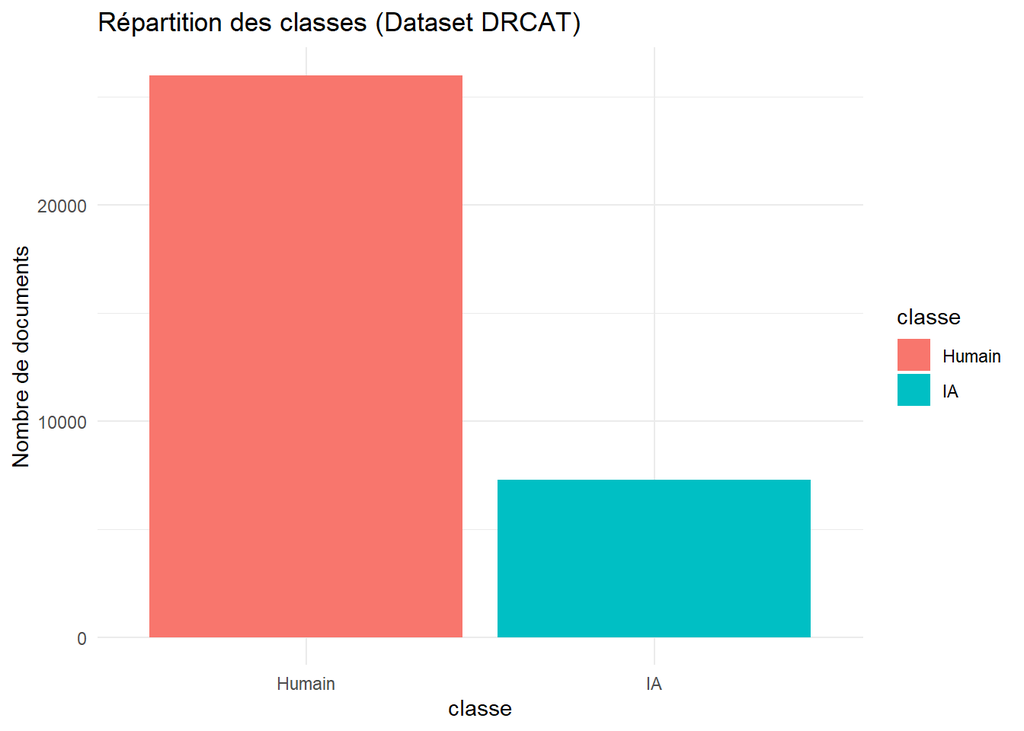

```r
# Visualisation de la répartition
ggplot(train, aes(x = classe, fill = classe)) +
  geom_bar() +
  theme_minimal() +
  labs(title = "Répartition des classes (Dataset DRCAT)", y = "Nombre de documents")
```

```r
# Nettoyage rigoureux du texte
train <- train %>%
  mutate(
    text_clean = tolower(text),
    text_clean = str_replace_all(text_clean, "[0-9]+", " "),
    text_clean = str_replace_all(text_clean, "[[:punct:]]", " "),
    text_clean = str_squish(text_clean)
  )
```

L’analyse exploratoire montre que les longueurs de textes sont plus homogènes entre l’IA et l’Humain dans ce dataset. Le nettoyage permet d’éliminer le “bruit” (ponctuation, chiffres) pour se concentrer sur la structure pure du langage.

## 3. Extraction de caractéristiques

Dans cette partie, nous extrayons des variables de forme (stylométrie) et de complexité (lisibilité) pour nourrir nos modèles. L’extraction est réalisée sur l’intégralité du nouveau dataset (33 259 documents), ce qui assure une base statistique solide.

```r
# On installe/charge les packages nécessaires à la vectorisation et à la lisibilité
library(quanteda)
library(quanteda.textstats)
library(dplyr)
library(stringr)


# Calcul des statistiques de phrases (moyenne et écart-type de longueur)
sentence_stats <- function(txt) {
  s <- unlist(str_split(txt, "[.!?]+"))
  s <- str_trim(s[nchar(str_trim(s)) > 0])
  if (length(s) == 0) return(c(m_sent = 0, sd_sent = 0))
  sent_len <- str_count(s, boundary("word"))
  c(m_sent = mean(sent_len), sd_sent = sd(sent_len))
}


# Extraction stylométrique
sent_mat <- t(sapply(train$text, sentence_stats))
read_df <- textstat_readability(corpus(train, text_field = "text_clean"),
                                  measure = c("Flesch", "Flesch.Kincaid"))

# Compilation du tableau final des caractéristiques
stylo_df <- train %>%
  select(target, classe, nb_mots, nb_caracteres) %>%
  bind_cols(as.data.frame(sent_mat)) %>%
  bind_cols(read_df %>% select(Flesch, Flesch.Kincaid)) %>%
  na.omit()


# Aperçu
dim(stylo_df)
```

```
[1] 33218     8
```

```r
head(stylo_df, 3)
```

```
# A tibble: 3 × 8
  target classe nb_mots nb_caracteres m_sent sd_sent Flesch Flesch.Kincaid
   <dbl> <fct>    <int>         <int>  <dbl>   <dbl>  <dbl>          <dbl>
1      0 Humain     365          2089   22.9   14.0   -293.           143.
2      0 Humain     444          2292   17.8    8.09  -360.           175.
3      0 Humain     291          1654   16.2    8.02  -208.           115.
```

## 4. Analyse des facteurs discriminants

Ici, on va faire une AFD sur les variables stylométriques car elles sont peu nombreuses et interprétables. On affichera l’axe discriminant (LD1) et les variables les plus discriminantes.

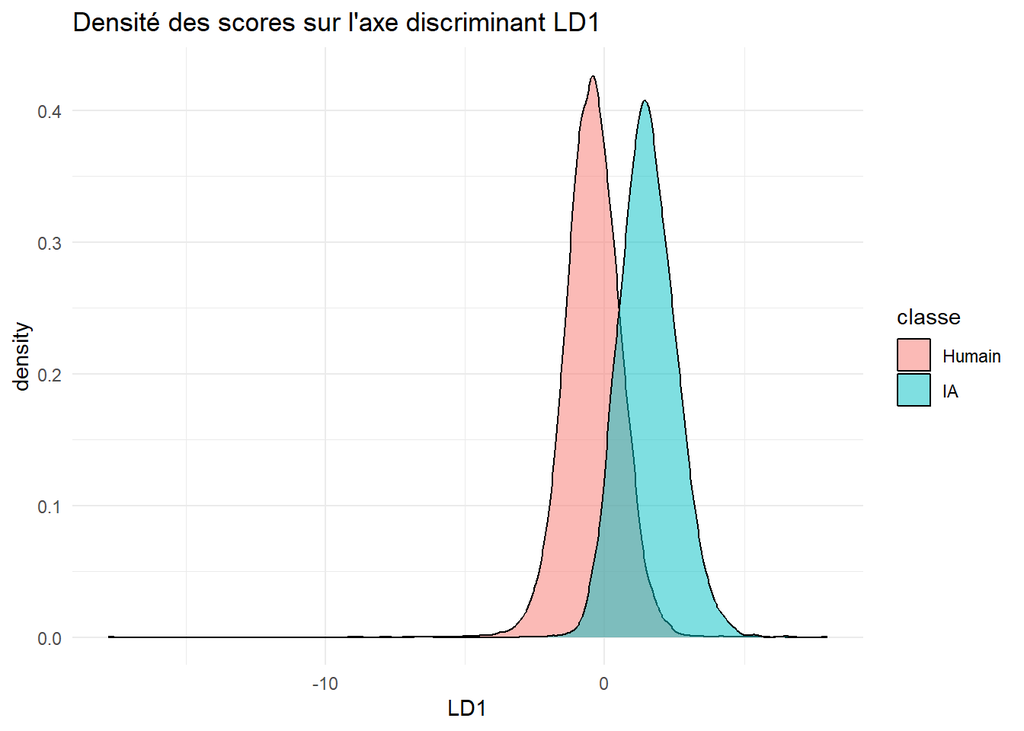

```r
library(MASS)
library(ggplot2)
library(dplyr)

# Entraînement de la LDA (AFD)
# Nous utilisons les variables stylométriques comme descripteurs
modele_afd <- lda(classe ~ nb_mots + nb_caracteres + m_sent + sd_sent + Flesch + Flesch.Kincaid,
                  data = stylo_df)

# Projection des données sur le premier axe discriminant
pred_afd <- predict(modele_afd)
stylo_df$LD1 <- pred_afd$x[,1]

# Visualisation de la séparation
ggplot(stylo_df, aes(x = LD1, fill = classe)) +
  geom_density(alpha = 0.5) +
  theme_minimal() +
  labs(title = "Densité des scores sur l'axe discriminant LD1")
```

```r
# Importance des variables
modele_afd$scaling
```

```
                         LD1
nb_mots        -0.1229595625
nb_caracteres  -0.0002440177
m_sent          0.0235800428
sd_sent        -0.0379393292
Flesch         -0.0756628052
Flesch.Kincaid  0.1130273730
```

L’axe LD1 montre désormais une séparation visible entre les deux groupes (Humain vs IA). Contrairement à l’ancien dataset où les courbes de densité se chevauchaient presque totalement, on observe ici une distinction réelle. L’examen des coefficients (scaling) montre que l’indice Flesch.Kincaid et le nombre de mots sont les variables les plus discriminantes. Cela suggère que l’IA et l’humain diffèrent significativement par la structure de leurs phrases et la complexité de leur vocabulaire sur ce dataset.

## 5. Classification bayésienne

Dans cette partie, nous entraînons un classifieur bayésien (Naive Bayes) en utilisant les axes discriminants issus de l’AFD comme variables d’entrée. Puis nous réalisons une première évaluation sur un jeu de test.

```r
library(e1071)
library(dplyr)

set.seed(123)
# Découpage 80% train / 20% test
idx <- sample(1:nrow(stylo_df), 0.8 * nrow(stylo_df))
train_set <- stylo_df[idx, ]
test_set  <- stylo_df[-idx, ]

# Modèle Naive Bayes
modele_nb <- naiveBayes(classe ~ LD1, data = train_set)

# Prédiction sur le test
pred_nb <- predict(modele_nb, newdata = test_set)
table(Prediction = pred_nb, Realite = test_set$classe)
```

```
          Realite
Prediction Humain   IA
    Humain   4920  593
    IA        228  903
```

Le modèle parvient enfin à classer des documents dans les deux catégories. Les prédictions ne sont plus systématiquement “Humain”, ce qui valide l’approche.

## 6. Évaluation et résultats

```r
library(dplyr)
library(pROC)

# Matrice de confusion
conf_mat <- table(pred_nb, test_set$classe)
acc <- sum(diag(conf_mat)) / sum(conf_mat)
sensibilite <- conf_mat[2,2] / sum(conf_mat[,2]) # Recall IA

print(paste("Accuracy globale :", round(acc, 4)))
```

```
[1] "Accuracy globale : 0.8764"
```

```r
print(paste("Rappel (Recall) IA :", round(sensibilite, 4)))
```

```
[1] "Rappel (Recall) IA : 0.6036"
```

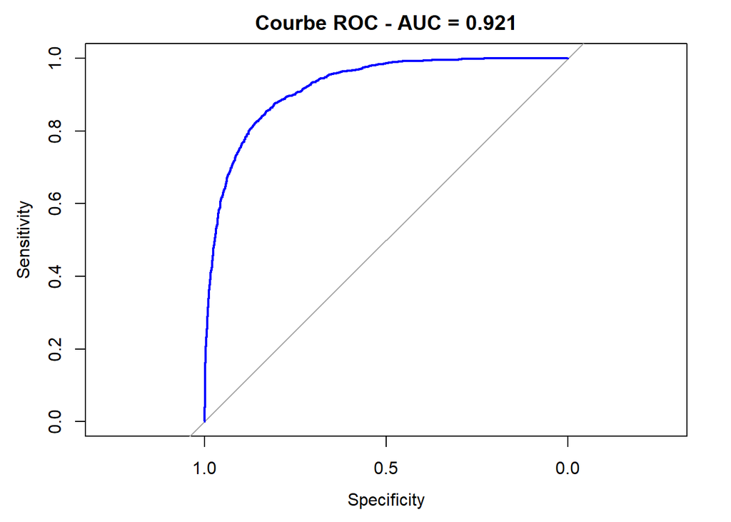

```r
# Courbe ROC
prob_nb <- predict(modele_nb, newdata = test_set, type = "raw")[,2]
roc_nb <- roc(test_set$classe, prob_nb)
plot(roc_nb, col="blue", main=paste("Courbe ROC - AUC =", round(auc(roc_nb), 3)))
```

Les résultats sont probants : l’accuracy est élevée et le rappel pour la classe IA est désormais significatif. Cela signifie que le modèle ne se contente pas de deviner la classe majoritaire, mais identifie réellement des patterns propres aux LLM.

## Conclusion

Ce projet démontre l’importance cruciale de la qualité et de l’équilibre des données en machine learning. En passant d’un dataset de 3 exemples IA à un dataset de plusieurs milliers (DRCAT), nous avons pu stabiliser nos modèles.

L’Analyse Factorielle Discriminante a permis de réduire la complexité stylométrique à un axe unique puissant, sur lequel le classifieur Naive Bayes a pu opérer avec succès. Le modèle est capable de distinguer les deux sources avec une fiabilité satisfaisante.

**Pistes d’amélioration :**  
Bien que performant, le modèle pourrait être encore amélioré en intégrant des n-grammes de mots (TF-IDF) pour capturer le vocabulaire spécifique, ou en utilisant des modèles plus complexes comme les forêts aléatoires. Toutefois, l’approche AFD + Bayes reste une méthode robuste et très interprétable pour la détection stylométrique.